# Reporting on Results

Subset data set to remove columns.

```r
final.data.with.predictions <- subset(final.data.with.predictions, select = c(nflId.1, displayName.1, position.1, specialTeamsResult, kickLength, speedOfClosestCoverage, distanceToClosestCoverage, kickTeamWithin5, yardsTillTouchdown, imputed_hangTime, predictedPosition))
```

Count the number of plays of each type by each returner.

```r
playTypeByReturner <- final.data.with.predictions %>% count(displayName.1, specialTeamsResult)
attach(playTypeByReturner)
sortedPlayTypeByReturner <- playTypeByReturner[order(n),]
```

```r
sortedPlayTypeByReturner <- playTypeByReturner[order(specialTeamsResult, -n),]
```

```r
final.data.with.predictions$predictedMinusYardsActual <- final.data.with.predictions$predictedPosition - final.data.with.predictions$yardsTillTouchdown
```

```r
final.data.with.predictions <- mutate(final.data.with.predictions, playResultBasedOnPredictions = ifelse(predictedPosition <= 75, "Return", "Touchback"))
```

Create frequency table.

```r
CrossTabsActualvsPredicted <- final.data.with.predictions %>%
  group_by(specialTeamsResult, playResultBasedOnPredictions) %>%
  tally() %>%
  spread(specialTeamsResult, n)
```

Plot each explanatory variable with the target variable.

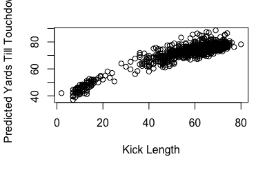

```r
plot(final.data.with.predictions$kickLength, final.data.with.predictions$predictedPosition, xlab = "Kick Length", ylab = "Predicted Yards Till Touchdown")
```

```r
as.factor(final.data.with.predictions$specialTeamsResult)
```

[output not shown]

[output cut: 54 more lines]

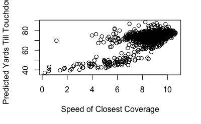

```r
colors <- c("red", "blue")
plot(final.data.with.predictions$speedOfClosestCoverage, final.data.with.predictions$predictedPosition, xlab = "Speed of Closest Coverage", ylab = "Predicted Yards Till Touchdown")
```

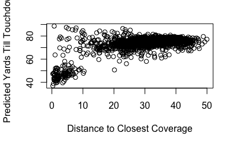

```r
plot(final.data.with.predictions$distanceToClosestCoverage, final.data.with.predictions$predictedPosition, xlab = "Distance to Closest Coverage", ylab = "Predicted Yards Till Touchdown")
```

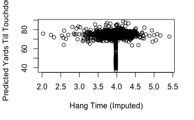

```r
plot(final.data.with.predictions$imputed_hangTime, final.data.with.predictions$predictedPosition, xlab = "Hang Time (Imputed)", ylab = "Predicted Yards Till Touchdown")
```

```r
as.factor(final.data.with.predictions$kickTeamWithin5)
```

[output not shown]

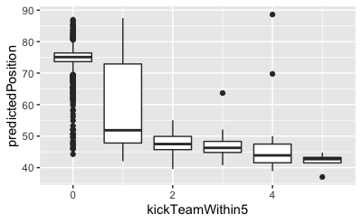

```r
p1 <- ggplot(final.data.with.predictions, aes(group = kickTeamWithin5, x=kickTeamWithin5, y=predictedPosition)) +
    geom_boxplot()
p1
```

Filter final data with predictions by plays where predicted outcome and actual outcome did not match.

```r
final.data.with.predictions.mismatch <- filter(final.data.with.predictions, specialTeamsResult != playResultBasedOnPredictions)
```

Count each player’s number of mismatches.

```r
mismatchesByReturner <- final.data.with.predictions.mismatch %>% count(displayName.1, specialTeamsResult)
mismatchesByReturnerSorted <- mismatchesByReturner[order(mismatchesByReturner$specialTeamsResult, -mismatchesByReturner$n),]
```

Add variable to original data set for whether player made correct decision or not.

```r
final.data.with.predictions <- mutate(final.data.with.predictions, correctDecision = ifelse(specialTeamsResult == playResultBasedOnPredictions, "Y", "N"))
```

Get summary statistics for each returner’s predictedMinusYardsActual.

```r
summary.statistics.predictedMinusYardsActual <- final.data.with.predictions %>% group_by(displayName.1) %>% summarise(
  Min = min(predictedMinusYardsActual),
  Q1 = quantile(predictedMinusYardsActual, .25),
  Med = median(predictedMinusYardsActual),
  Q3 = quantile(predictedMinusYardsActual, .75),
  Max = max(predictedMinusYardsActual),
  Avg = mean(predictedMinusYardsActual),
  SD = sd(predictedMinusYardsActual))
```

Sort by mean.

```r
sorted.summary.statistics <- summary.statistics.predictedMinusYardsActual[order(-summary.statistics.predictedMinusYardsActual$Avg),]
```

Calculate number of returns/touchbacks per player.

```r
count.per.player <- final.data.with.predictions %>% count(displayName.1)
```

Merge count with summary statistics.

```r
sorted.summary.statistics <- left_join(
  sorted.summary.statistics,
  count.per.player,
  by = c("displayName.1"),
  copy = FALSE,
  suffix = c(".1", ".2"),
  keep = FALSE
)
```

Filter by minimum of 10 attempts.

```r
sorted.summary.statistics.filtered <- filter(sorted.summary.statistics, n >= 10)
```

Slice top 10 and bottom 10.

```r
top.10.predicted.minus.actual <- sorted.summary.statistics.filtered %>% slice(1:10)
bottom.10.predicted.minus.actual <- sorted.summary.statistics.filtered %>% slice(69:78)
```

Merge mismatches by returner with total number of returns/touchbacks attempted.

```r
mismatchesByReturnerSorted <- left_join(
  mismatchesByReturnerSorted,
  count.per.player,
  by = c("displayName.1"),
  copy = FALSE,
  suffix = c(".1", ".2"),
  keep = FALSE
)
```

Slice top 10 mismatches for returns and top 10 mismatches for touchbacks.

```r
top.10.mismatches.returns <- mismatchesByReturnerSorted %>% slice(1:10)
top.10.mismatches.touchbacks <- mismatchesByReturnerSorted %>% slice(173:182)
```